# MDS simulation

I want to show you that it is often suboptimal to use the default sklearn parameters.

So far, we learned various properties for various machine learning algorithms, but in practice, you often don't see them. This is partly because in many cases, we are approximating the solution using optimization methods instead of solving the analytical solution.

Take multidimensional scaling (MDS) for example, which is covered this week. Though it operates on the distance matrix of the data, and the distances don't change when you re-order the data, but the MDS solution often does change when you re-order the data...

Playing with the error threshold is useful here. For [the MDS in sklearn](https://scikit-learn.org/stable/modules/generated/sklearn.manifold.MDS.html) (the list of input arguments are listed below), `eps`, `n_init`, `max_iter` are parameters that affect the "error tolerance" of optimization procedure. So to get stable MDS fitting, you might want to play with these parameters.

```
sklearn.manifold.MDS(n_components=2, *, metric=True, n_init=4, max_iter=300, verbose=0, eps=0.001, n_jobs=None, random_state=None, dissimilarity='euclidean')
```

In the following toy simulation, you will see that the default parameters of the MDS are not strict enough, and using a more stringent criterion helped to stabilize the results. In particular, I sampled some data points from N-D space and tried to embed these points into a 2-D space. With the default parameters (e.g. `eps=0.001`), re-ordering the data changes MDS solution. When I used a more stringent criterion, the solution is more order invariant.

This point is not specific to MDS, of course. In most cases, the default parameters in sklearn are unlikely to be optimal for your data. Similarly, playing with hyperparameter tuning is often useful.

This is a toy simulation made for PSY/NEU/ELE 480 @ taught at Princeton Spring 2021. Comment/suggestion appreciated: qlu@princeton.edu

```python
import numpy as np
import matplotlib.pyplot as plt
import seaborn as sns
from sklearn.manifold import MDS
from sklearn.decomposition import PCA
from sklearn.metrics import euclidean_distances

sns.set(style='white', context='talk')

"""make some data"""
# params
seed = 0
n_pts = 5
n_dim = 20

np.random.seed(seed)
# make data
X = np.random.uniform(size=(n_pts, n_dim))
# permute data
perm_ids = np.random.permutation(n_pts)
unperm_ids = [perm_ids[i] for i in range(len(perm_ids))]
X_perm = X[perm_ids, :]

# get some colors
cur_pals = sns.color_palette(n_colors=n_pts)
cur_pals_perm = [cur_pals[perm_ids[i]] for i in range(n_pts)]
```

```
MDS - Embed 5 points from 20-D space to 2D
```

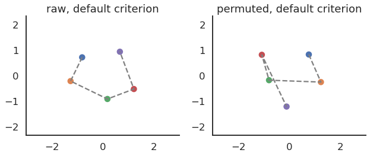

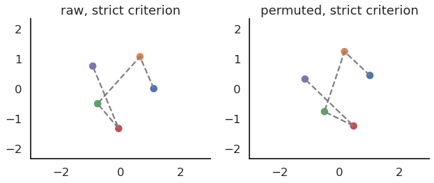

```python
"""fit MDS"""
# choose some params for MDS fitting
n_inits = [4, 20]
max_iters = [300, 1000]
eps = [1e-3, 1e-10]
criterion_list = ['default criterion', 'strict criterion']
print('MDS - Embed %d points from %d-D space to 2D ' % (n_pts, n_dim))

# loop over different stopping criteria
alpha = 1
length = 3
for i, criterion in enumerate(criterion_list):
    # fit MDS on the raw data
    mds = MDS(
        n_components=2, random_state=seed,
        eps=eps[i], n_init=n_inits[i], max_iter=max_iters[i],

    )
    Y = mds.fit_transform(X)
    # fit MDS on the permuted data
    mds_perm = MDS(
        n_components=2, random_state=seed,
        eps=eps[i], n_init=n_inits[i], max_iter=max_iters[i],
    )
    Y_perm = mds_perm.fit_transform(X_perm)

    """plot the solution"""

    f, axes = plt.subplots(1, 2, figsize=(9, 4))
    axes[0].plot(Y[:,0], Y[:,1], color='grey', alpha=alpha, linestyle = '--')
    axes[0].scatter(Y[:,0], Y[:,1], c = cur_pals)
    axes[0].set_title(f'raw, {criterion}')

    Y_unperm = Y_perm[unperm_ids]
    axes[1].plot(Y_unperm[:,0],Y_unperm[:,1], color='grey', alpha=alpha, linestyle = '--')
    axes[1].scatter(Y_unperm[:,0], Y_unperm[:,1], c = cur_pals)
    axes[1].set_title(f'permuted, {criterion}')
    for i in range(len(axes)):
        axes[i].axis('equal')
        axes[i].axis([-length, length, -length, length])
    f.tight_layout()
    sns.despine()
```

In the lab notebook, there is a toy simulation that embeds a line into N-D space. The result shows that as N gets bigger, the stress increases. Why is that? Well, before you think too hard, note that if we use a strict stopping criterion, that pattern no longer holds... Can you explain why?

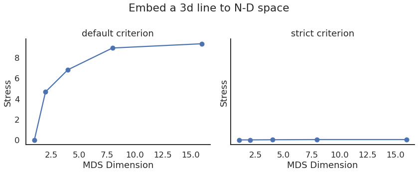

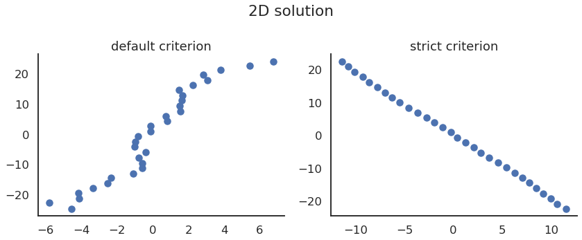

```python
# sample data
n_pts = 30
coords = np.linspace(1, n_pts, n_pts)
coords = np.vstack((coords, coords, coords)).T

distance_matrix = euclidean_distances(coords)
n_components_list = [1, 2, 4, 8, 16]

# plot the stress over the dimension of MDS
Y = {c: [] for c in criterion_list}
f, axes = plt.subplots(1, 2, figsize=(12, 5), sharey=True)
for i, criterion in enumerate(criterion_list):
    mds_list = []
    stress = []
    for k in n_components_list:
        mds = MDS(
            n_components=k, dissimilarity="precomputed", random_state=seed,
            eps=eps[i], n_init=n_inits[i], max_iter=max_iters[i],
        )
        Y[criterion].append(mds.fit_transform(distance_matrix))
        stress.append(mds.stress_)

    axes[i].plot(n_components_list, stress, marker = 'o')
    axes[i].set_title(f'{criterion}')
    axes[i].set_ylabel('Stress')
    axes[i].set_xlabel('MDS Dimension')
    sns.despine()
f.suptitle(f'Embed a 3d line to N-D space')
f.tight_layout()

# plot the 2D solution
f, axes = plt.subplots(1, 2, figsize=(12, 5))
k_id = 1
for i, criterion in enumerate(criterion_list):
    axes[i].scatter(Y[criterion][k_id][:,0], Y[criterion][k_id][:,1])
    axes[i].set_title(criterion)
    sns.despine()
f.suptitle(f'2D solution')
f.tight_layout()
```

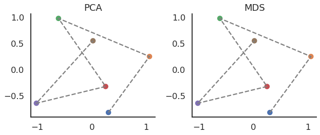

```python
# sample data
n_pts = 6
X = np.random.uniform(size=(n_pts, n_dim))
cur_pals = sns.color_palette(n_colors=n_pts)

# embed the data to 2d space
pca = PCA(n_components=2,random_state=seed)
X_pc = pca.fit_transform(X)

mds = MDS(n_components=2, random_state=seed)
X_mds = pca.fit_transform(X)

# plot the embeddings
dim_reduced_data = [X_pc, X_mds]
names = ['PCA', 'MDS']
f,axes = plt.subplots(1,2, figsize=(9,4))
for i, X_ in enumerate(dim_reduced_data):
    axes[i].plot(X_[:,0], X_[:,1], color='grey', alpha=alpha, linestyle = '--')
    axes[i].scatter(X_[:,0], X_[:,1], color = cur_pals)
    axes[i].set_title(names[i])
f.tight_layout()
sns.despine()
```